# Monitoring_Server_Log

Victor Adrian Martinez

2023-04-25

**[link Github](https://github.com/ingvamartinez/Monitorizacion_Data_Mining)**

https://github.com/ingvamartinez/Monitorizacion_Data_Mining

#Actividad: Monitoreo de log de servidor

## Actividad 1

#### Análisis de logs de servidor usando R

#### Pregunta 1:

Queremos programar un script con el que podamos hacer una investigación forense sobre un fichero de logs de un servidor de tipo Apache. Los datos del registro del servidor están en el formato estándar e incluyen miles de registros sobre las distintas peticiones gestionadas por el servidor web.

Nuestro programa ha de ser capaz de obtener las respuestas de forma dinámica a las siguientes preguntas utilizando instrucciones de código en R: 1. Descomprimir el fichero comprimido que contiene los registros del servidor, y a partir de los datos extraídos, cargar en data frames los registros con las peticiones servidas.

El primer paso para realizartareas de análisis consiste en la carga de los datos, la exploración inicial y limpieza de los datos (filtrado, corrección de tipo de datos, ajuste de la forma de los datos, etc.). Para esto usaremos la capacidad de R y de sus librerías (tidyr y dplyr) para modificar los data frames cargados y adaptarlos a la estructura de datos elegantes: cada fila se corresponderá a una observación y cada columna únicamente una variable.

De esta forma, se facilita el análisis y la posterior modificación de la forma del data frame, adaptando este para que pueda ser usado en la mayoría de funciones de R.

```r
{
library(dplyr)
library(tidyr)
library(stringr)

# Obtenemos la Data

data_path<-"epa-http.csv"

data<-read.csv(data_path, col.names = c('Request.IP','Request_DATE',
'Request_Solicitud', 'Status', 'Size') , sep=" ", header = FALSE)

# Relizamos la siguientes operaciones para obtener un DF con todos los datos

data_sol<-as.data.frame(data$V3)
data_sol <- str_split_fixed(data$Request_Solicitud," ",3)
data_sol <- as.data.frame(data_sol)
data_sol <- rename(data_sol,c(RequestType = V1, RequestUrl = V2, RequestProtocol =
V3))
datafull <- cbind.data.frame(data,data_sol)

head(datafull,2) }
```

```
##                Request.IP  Request_DATE           Request_Solicitud Status Size
## 1           141.243.1.172 [29:23:53:25] GET /Software.html HTTP/1.0    200 1497
## 2 query2.lycos.cs.cmu.edu [29:23:53:36] GET /Consumer.html HTTP/1.0    200 1325
##   RequestType     RequestUrl RequestProtocol
## 1         GET /Software.html        HTTP/1.0
## 2         GET /Consumer.html        HTTP/1.0
```

#### Pregunta 2:

Explorar el contenido del fichero descomprimido y cargado en un data frame. Identificar el número único de usuarios que han interactuado directamente con el servidor de forma segregada según si los usuarios han tenido algún tipo de error en las distintas peticiones ofrecidas por el servidor.Idealmente, hacer el break down del número de usuarios en función de si estos han tenido algún tipo de error durante las interacciones con el servidor, es decir, ofrecer el número de usuarios que no han tenido ningún error en una de las peticiones gestionadas por el servidor y el caso contrario, el número de usuarios que sí han experimentado algún error para una petición servida.

Para determinar si una respuesta ha sido servida de forma satisfactoria o no se puede usar el codigo de retorno de la petición. Los códigos de retorno pertenecientes a familia de los 200, se pueden considerar peticiones servidas correctamente.

```r
print('Numero de Ips sin errores')
```

```
## [1] "Numero de Ips sin errores"
```

```r
#Seleccionamos las variables que necesitamos
ip_errors<- subset(datafull, select=c(Request.IP,Status))
ip_errors<- as.data.frame(ip_errors)
#Agregamos una columna para clasificar si tiene error
ip_errors$error <- ifelse(ip_errors$Status != 200,1,0)
ip_errors<-as.data.frame(subset(ip_errors,error == 1))
g_errors<- ip_errors %>%  group_by(Request.IP) %>%
   summarise(sum = sum(error))
#Realizamos la suma aritmetica para obtener la cantidad de los usuarios con errores y sin errores
IP_error<- length(unique(g_errors$Request.IP))
IP_total<- length(unique(datafull$Request.IP))
IP_noerror <- IP_total-IP_error
print(paste('Usuarios Totales=',IP_total))
```

```
## [1] "Usuarios Totales= 2333"
```

```r
print(paste('Usuarios sin errores=', IP_noerror))
```

```
## [1] "Usuarios sin errores= 1089"
```

```r
print(paste('Usuarios con errores=', IP_error))
```

```
## [1] "Usuarios con errores= 1244"
```

#### Pregunta 3:

Analizar los distintos tipos de peticiones HTTP (GET, POST, PUT, DELETE) gestionadas por el servidor, identificando la frecuencia de cada una de estas. Repetir el análisis, esta vez filtrando previamente aquellas peticiones correspondientes a recursos ofrecidos de tipo imagen.

```r
#Pregunta 3

#Analizar los distintos tipos de peticiones HTTP (GET, POST, PUT, DELETE)
#gestionadas por el servidor, identificando la frecuencia de cada una de estas.

frec_Prot_http<- data.frame(table(datafull$RequestType))
head(frec_Prot_http)
```

```
##   Var1  Freq
## 1  GET 46020
## 2 HEAD   106
## 3 POST  1622
```

```r
#Repetir el análisis, esta vez filtrando previamente aquellas peticiones
#correspondientes a recursos ofrecidos de tipo imagen.
tipo_imagen<- grepl(pattern = ".*[png|jpg|gif|ico]$", datafull$RequestUrl)
tipo_imagen<- as.data.frame(tipo_imagen)
datafull2<-cbind.data.frame(datafull,tipo_imagen)
table_df2<- datafull2 %>% select(RequestType,tipo_imagen)
table_df2<- as.data.frame(subset(table_df2,tipo_imagen == TRUE))
frec_prot_img<- data.frame(table(table_df2$RequestType))
head(frec_prot_img)
```

```
##   Var1  Freq
## 1  GET 22676
## 2 HEAD    57
## 3 POST   232
```

#### Pregunta 4:

Generar un gráfico que permita visualizar las respuestas del servidor, es decir, la distribución de peticiones según el código de respuesta de esta.

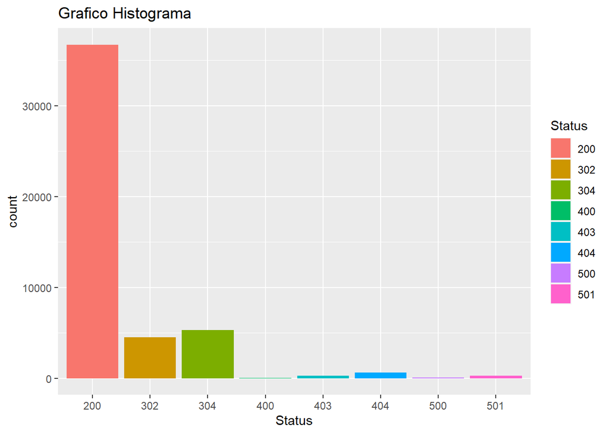

```r
# Graficos

library(ggplot2)
df4 <- as.data.frame(datafull)
df4$Status <- as.factor(df4$Status)
#1
gf_Hist<-ggplot(df4, aes(Status, fill = Status))  + geom_histogram(bin=10,stat = "count")+
  labs(title="Grafico Histograma")
gf_Hist
```

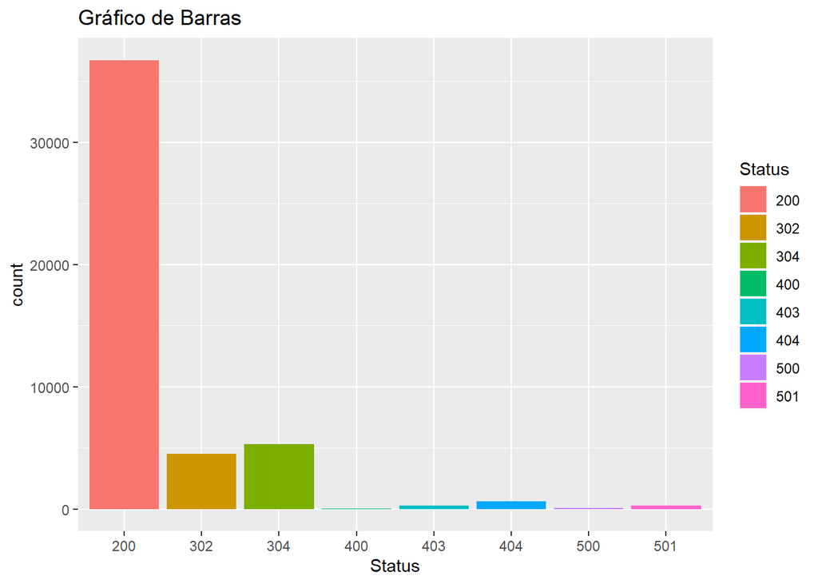

```r
#2
gf_Bar<-ggplot(df4, aes(Status, fill = Status)) + geom_bar(stat = "count")+
  labs(title="Gráfico de Barras")
gf_Bar
```

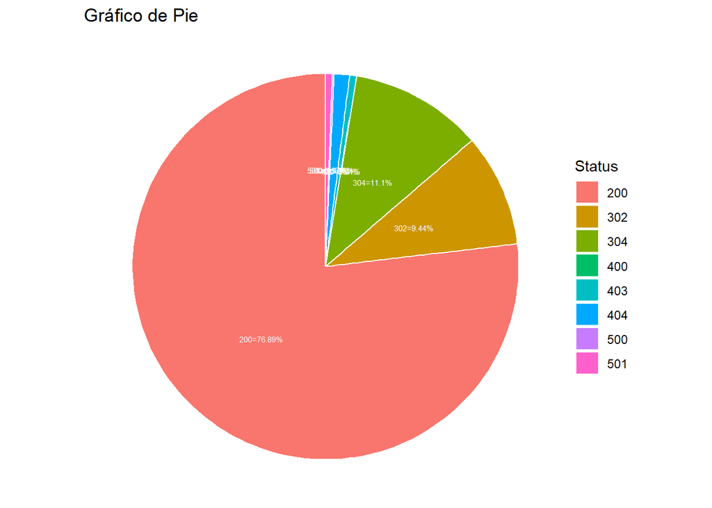

```r
#3
sumVec<-as.character(df4$Status)
table_status<-table(sumVec)
df5<-data.frame(table_status)
df5<-rename(df5,c(Status=sumVec, Url=Freq))
etiquetas <- paste0(df5$Status,"=",round(100 * df5$Url/sum(df5$Url), 2), "%")

gf_Pie<- ggplot(df5,aes(x=" ",y=Url, fill= Status))+
  geom_bar(stat = "identity",color="white" )+
  geom_text(aes(label=etiquetas),
            position=position_stack(vjust=0.5),color="white",size=2)+
  coord_polar(theta="y")+
  theme_void()+
  labs(title="Gráfico de Pie")
gf_Pie
```

[output not shown]